# Menú Principal · Estudiante · SIAAF Prácticas

**Siaaf**Prácticas preprofesionales

Módulo académico

Periodo académico**MAR.26-AGO.26 GRADO**

Semana 9 de 16

**UNL**Universidad  
Nacional de Loja

# Sistema de Información Académico, Administrativo y Financiero

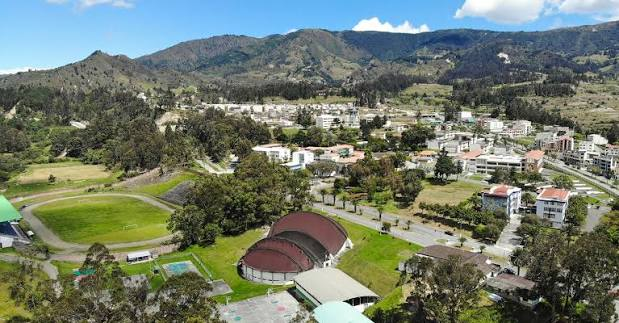

## Bienvenida

¡Hola, Luciana!

Inicio

MENDIETA SARANGO  
LUCIANA BELÉN

Periodo MAR.26-AGO.26 GRADO

### Mi práctica

Computación · Práctica laboral · Semana 9 de 16

**Entidad receptora**

Municipio de Loja · Dirección de Tecnologías

**Estado**

En curso Al día

**Tutor académico**

Paredes Jaramillo Roberto Andrés

**Tutora de la entidad**

Celi Armijos Martha Cecilia

Ir a mi práctica

### Avance de horas

Solo cuentan las horas validadas por su tutor académico.

**96 h**validadas de 240 h requeridas

- Validadas: 96 h
- En revisión: 16 h
- Esperadas a la fecha: 135 h

Va por encima del umbral de **108 h** (80 % de lo esperado, contando las horas en revisión). Le faltan **144 h** por validar para completar la práctica.

Nuevo reporte semanal Informe final

### Pendiente de atención

2 reportes necesitan acción.

- Devuelto con observación**Semana 7**

  **Observación:** detalle las actividades del jueves y especifique cuántas de las 8 h corresponden a cada una.

  Corregir reporte
- Sin reporte**Semana 9**

  Aún no envía el reporte de esta semana (01/06 – 07/06).

  Reportar semana 9

### Últimos reportes semanales

- **Semana 8**25 – 31 de mayo16 hEn revisión
- **Semana 7**18 – 24 de mayo8 hDevuelto
- **Semana 6**11 – 17 de mayo16 hValidado
- **Semana 5**04 – 10 de mayo16 hValidado

Guía de la propuesta